# statsExpressions: R Package for Tidy Dataframes and Expressions with Statistical Details

## Summary

The `{statsExpressions}` package has two key aims: to provide a consistent syntax to do statistical analysis with tidy data, and to provide statistical expressions (i.e., pre-formatted in-text statistical results) for plotting functions. Currently, it supports common types of statistical approaches and tests: parametric, nonparametric, robust, and Bayesian *t*-test, one-way ANOVA, correlation analyses, contingency table analyses, and meta-analyses. The functions are pipe-friendly and compatible with tidy data.

## Statement of need

Statistical packages exhibit substantial diversity in terms of their syntax and expected input and output data type. For example, some functions expect vectors as inputs, while others expect data frames. Depending on whether it is a repeated measures design or not, functions from the same package might expect data to be in wide or tidy format. Some functions can internally omit missing values, while others do not. Furthermore, the statistical test objects returned by the test functions might not have all required information (e.g., degrees of freedom, significance, Bayes factor, etc.) accessible in a consistent data type. Depending on the specific test object and statistic in question, details may be returned as a list, a matrix, an array, or a data frame. This diversity can make it difficult to easily access all needed information for hypothesis testing and estimation, and to switch from one statistical approach to another.

This is where `{statsExpressions}` comes in: It can be thought of as a unified portal through which most of the functionality in these underlying packages can be accessed, with a simpler interface and with tidy data format.

## Comparison to other packages

Unlike `{broom}` (Robinson, Hayes, & Couch, 2021) or `{parameters}` (Lüdecke, Ben-Shachar, Patil, & Makowski, 2020), the goal of `{statsExpressions}` is not to convert model objects into tidy data frames, but to provide a consistent and easy syntax to carry out statistical tests. Additionally, none of these packages return statistical expressions.

## Consistent syntax for statistical analysis

The package offers functions that allow users to choose a statistical approach without changing the syntax (i.e., by only specifying a single argument). The functions always require a data frame in tidy format (Wickham et al., 2019), and work with missing data. Moreover, they always return a data frame that can be further utilized downstream in the workflow (such as visualization).

| Function | Analysis | Parametric | Non-parametric | Robust | Bayesian |
| --- | --- | --- | --- | --- | --- |
| `one_sample_test()` | one-sample test | ✅ | ✅ | ✅ | ✅ |
| `two_sample_test()` | two-sample test | ✅ | ✅ | ✅ | ✅ |
| `oneway_anova()` | one-way ANOVA | ✅ | ✅ | ✅ | ✅ |
| `corr_test()` | correlation | ✅ | ✅ | ✅ | ✅ |
| `contingency_table()` | one- or two-way contingency table | ✅ | ✅ | ❌ | ✅ |
| `meta_analysis()` | random-effects meta-analysis | ✅ | ❌ | ✅ | ✅ |
| `pairwise_comparisons()` | pairwise group comparisons | ✅ | ✅ | ✅ | ✅ |
| `centrality_description()` | centrality and distribution | ✅ | ✅ | ✅ | ✅ |

`pairwise_contingency_table()` provides pairwise Fisher’s exact tests with Cramer’s *V* effect sizes. It does not have a `type` argument.

For the tests, effect sizes, and underlying functions used by each analysis, see [Test and effect size details](https://www.indrapatil.com/statsExpressions/articles/stats_details.html).

`{statsExpressions}` internally relies on `{stats}` package for parametric and non-parametric (R Core Team, 2021), `{WRS2}` package for robust (Mair & Wilcox, 2020), and `{BayesFactor}` package for Bayesian statistics (Morey & Rouder, 2020). The random-effects meta-analysis is carried out using `{metafor}` (parametric) (Viechtbauer, 2010), `{metaplus}` (robust) (Beath, 2016), and `{metaBMA}` (Bayesian) (Heck et al., 2019) packages. Additionally, it relies on `easystats` packages (Ben-Shachar, Lüdecke, & Makowski, 2020; Lüdecke et al., 2020; Lüdecke, Ben-Shachar, Patil, Waggoner, & Makowski, 2021; Lüdecke, Waggoner, & Makowski, 2019; Makowski, Ben-Shachar, & Lüdecke, 2019; Makowski, Ben-Shachar, Patil, & Lüdecke, 2020) to compute appropriate effect size/posterior estimates and their confidence/credible intervals.

## Tidy dataframes from statistical analysis

To illustrate the simplicity of this syntax, let’s say we want to run a one-way ANOVA. If we first run a non-parametric ANOVA and then decide to run a robust ANOVA instead, the syntax remains the same and the statistical approach can be modified by changing a single argument:

```r
oneway_anova(mtcars, cyl, wt, type = "nonparametric")
```

```
#> # A tibble: 1 × 15
#>   parameter1 parameter2 statistic df.error   p.value
#>   <chr>      <chr>          <dbl>    <int>     <dbl>
#> 1 wt         cyl             22.8        2 0.0000112
#>   method                       effectsize      estimate conf.level conf.low
#>   <chr>                        <chr>              <dbl>      <dbl>    <dbl>
#> 1 Kruskal-Wallis rank sum test Epsilon2 (rank)    0.736       0.95    0.624
#>   conf.high conf.method          conf.iterations n.obs expression
#>       <dbl> <chr>                          <int> <int> <list>
#> 1         1 percentile bootstrap             100    32 <language>
```

```r
oneway_anova(mtcars, cyl, wt, type = "robust")
```

```
#> # A tibble: 1 × 12
#>   statistic    df df.error p.value
#>       <dbl> <dbl>    <dbl>   <dbl>
#> 1      12.7     2     12.2 0.00102
#>   method
#>   <chr>
#> 1 A heteroscedastic one-way ANOVA for trimmed means
#>   effectsize                         estimate conf.level conf.low conf.high
#>   <chr>                                 <dbl>      <dbl>    <dbl>     <dbl>
#> 1 Explanatory measure of effect size     1.05       0.95    0.843      1.50
#>   n.obs expression
#>   <int> <list>
#> 1    32 <language>
```

These functions are also compatible with other popular data manipulation packages. For example, we can use combination of `{dplyr}` and `{statsExpressions}` to repeat the same statistical analysis across grouping variables.

```r
# running one-sample proportion test for `vs` at all levels of `am`
mtcars |>
  group_by(am) |>
  group_modify(~ contingency_table(.x, vs), .keep = TRUE) |>
  ungroup()
```

```
#> # A tibble: 2 × 14
#>      am statistic    df p.value method   effectsize estimate conf.level conf.low
#>   <dbl>     <dbl> <dbl>   <dbl> <chr>    <chr>         <dbl>      <dbl>    <dbl>
#> 1     0    1.32       1   0.251 Chi-squ… Pearson's…   0.254        0.95        0
#> 2     1    0.0769     1   0.782 Chi-squ… Pearson's…   0.0767       0.95        0
#> # ℹ 5 more variables: conf.high <dbl>, conf.method <chr>,
#> #   conf.distribution <chr>, n.obs <int>, expression <list>
```

## Custom statistical workflows

### Pairwise comparisons with automatic *p*-value adjustment

When an omnibus test (e.g., one-way ANOVA) is significant, you typically follow up with pairwise comparisons. The `pairwise_comparisons()` function handles this with built-in *p*-value adjustment across all pairwise tests:

```r
pairwise_comparisons(
  data            = mtcars,
  x               = cyl,
  y               = wt,
  type            = "parametric",
  var.equal       = FALSE,
  p.adjust.method = "holm"
)
```

```
#> # A tibble: 3 × 9
#>   group1 group2 statistic   p.value alternative distribution p.adjust.method
#>   <chr>  <chr>      <dbl>     <dbl> <chr>       <chr>        <chr>
#> 1 4      6           5.39 0.00831   two.sided   q            Holm
#> 2 4      8           9.11 0.0000124 two.sided   q            Holm
#> 3 6      8           5.12 0.00831   two.sided   q            Holm
#>   test         expression
#>   <chr>        <list>
#> 1 Games-Howell <language>
#> 2 Games-Howell <language>
#> 3 Games-Howell <language>
```

Each row contains a formatted `expression` column with the adjusted *p*-value, ready for use as a plot annotation. The `p.adjust.method` argument supports all methods from `stats::p.adjust()` (e.g., `"holm"`, `"bonferroni"`, `"BH"`, `"fdr"`, `"none"`).

### Chaining multiple tests and adjusting *p*-values

You can chain different statistical tests on the same data, consolidate the results into a single data frame, and apply *p*-value correction across all comparisons:

```r
multi_test_results <- dplyr::bind_rows(
  two_sample_test(mtcars, am, wt, type = "parametric"),
  two_sample_test(mtcars, am, wt, type = "nonparametric"),
  two_sample_test(mtcars, am, wt, type = "robust")
) |>
  dplyr::mutate(p.value = stats::p.adjust(p.value, method = "holm"))

dplyr::select(multi_test_results, method, effectsize, estimate, p.value)
```

```
#> # A tibble: 3 × 4
#>   method
#>   <chr>
#> 1 Welch Two Sample t-test
#> 2 Wilcoxon rank sum test
#> 3 Yuen's test on trimmed means for independent samples
#>   effectsize                                              estimate   p.value
#>   <chr>                                                      <dbl>     <dbl>
#> 1 Hedges' g                                                  1.88  0.0000188
#> 2 r (rank biserial)                                          0.866 0.0000869
#> 3 Algina-Keselman-Penfield robust standardized difference    2.48  0.0000869
```

Changing `p.value` after a test does not update its existing `expression` column. The example selects the adjusted numeric results only; the original expressions still contain the unadjusted *p*-values.

### Expressions from model results

For a fitted model, use `tidy_model_parameters()` to extract a tidy data frame, then `tidy_model_expressions()` to add plotmath expressions. The lower-level `add_expression_col()` helper is intended for internal use and its interface is not stable.

## Expressions for plots

In addition to other details contained in the data frame, there is also a column titled `expression`, which contains a pre-formatted text with statistical details. These expressions (Figure 1) attempt to follow the gold standard in statistical reporting for both Bayesian (Doorn et al., 2020) and Frequentist (American Psychological Association and others, 2019) frameworks.

[figure not shown]

The templates used in `{statsExpressions}` to display statistical details in a plot.

This expression can be easily displayed in a plot (Figure 2). Displaying statistical results in the context of a visualization is indeed a philosophy adopted by the `{ggstatsplot}` package (Patil, 2021), and `{statsExpressions}` functions as its statistical processing backend.

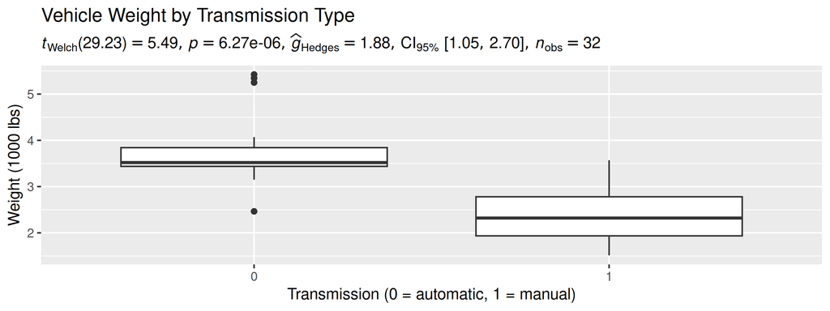

Example illustrating how `{statsExpressions}` functions can be used to display results from a statistical test in a plot.

```r
# needed libraries
library(ggplot2)

# Example 1: Performing a t-test on raw tidy data and extracting the formatted expression
# for direct use in a plot annotation
res_ttest <- two_sample_test(mtcars, am, wt, type = "parametric")

ggplot(mtcars, aes(as.factor(am), wt)) +
  geom_boxplot() +
  labs(
    x = "Transmission (0 = automatic, 1 = manual)",
    y = "Weight (1000 lbs)",
    title = "Vehicle Weight by Transmission Type",
    subtitle = res_ttest$expression[[1]] # Extract formatted p-value and effect size
  )
```

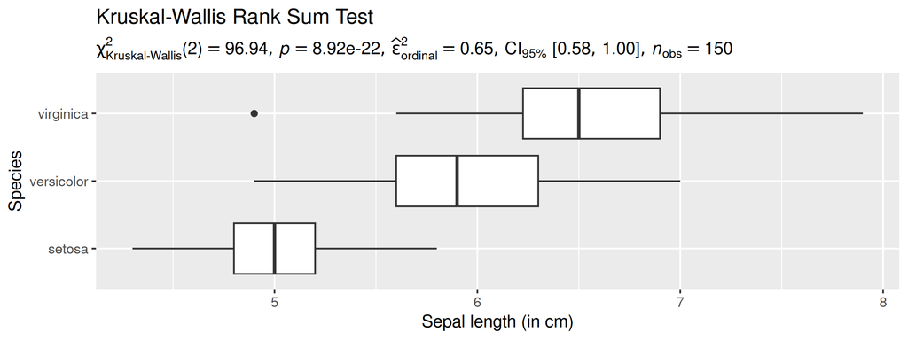

Example illustrating how `{statsExpressions}` functions can be used to display results from a statistical test in a plot.

```r
# Example 2: One-way ANOVA
res_anova <- oneway_anova(iris, Species, Sepal.Length, type = "nonparametric")

ggplot(iris, aes(x = Sepal.Length, y = Species)) +
  geom_boxplot() + # use 'expression' column to display results in the subtitle
  labs(
    x = "Sepal length (in cm)",
    y = "Species",
    title = "Kruskal-Wallis Rank Sum Test",
    subtitle = res_anova$expression[[1]]
  )
```

## Licensing and availability

`{statsExpressions}` is licensed under the MIT License, with all source code stored at [GitHub](https://github.com/IndrajeetPatil/statsExpressions/). In the spirit of honest and open science, requests and suggestions for fixes, feature updates, as well as general questions and concerns are encouraged via direct interaction with contributors and developers by filing an [issue](https://github.com/IndrajeetPatil/statsExpressions/issues).

## Acknowledgements

I would like to acknowledge the support of Mina Cikara, Fiery Cushman, and Iyad Rahwan during the development of this project. `{statsExpressions}` relies heavily on the [`easystats`](https://github.com/easystats/easystats) ecosystem, a collaborative project created to facilitate the usage of `R` for statistical analyses. Thus, I would like to thank the [members of easystats](https://github.com/orgs/easystats/people) as well as the users.

## References

American Psychological Association and others. (2019). *Publication Manual of the American Psychological Association* (7th Edition.). American Psychological Association.

Beath, K. J. (2016). metaplus: An R package for the analysis of robust meta-analysis and meta-regression. *R Journal*, *8*(1), 5–16. doi:10.32614/RJ-2016-001

Ben-Shachar, M. S., Lüdecke, D., & Makowski, D. (2020). effectsize: Estimation of effect size indices and standardized parameters. *Journal of Open Source Software*, *5*(56), 2815. doi:10.21105/joss.02815

Doorn, J. van, Bergh, D. van den, Böhm, U., Dablander, F., Derks, K., Draws, T., Etz, A., et al. (2020). The JASP guidelines for conducting and reporting a bayesian analysis. *Psychonomic Bulletin & Review*, 1–14. doi:10.3758/s13423-020-01798-5

Heck, W., D., Gronau, F., Q., Wagenmakers, &, & E.-J. (2019). *metaBMA: Bayesian model averaging for random and fixed effects meta-analysis*. Retrieved from https://CRAN.R-project.org/package=metaBMA

Lüdecke, D., Ben-Shachar, M. S., Patil, I., & Makowski, D. (2020). parameters: Extracting, computing and exploring the parameters of statistical models using R. *Journal of Open Source Software*, *5*(53), 2445. doi:10.21105/joss.02445

Lüdecke, D., Ben-Shachar, M. S., Patil, I., Waggoner, P., & Makowski, D. (2021). performance: An R package for assessment, comparison and testing of statistical models. *Journal of Open Source Software*, *6*(60), 3139. doi:10.21105/joss.03139

Lüdecke, D., Waggoner, P., & Makowski, D. (2019). insight: A unified interface to access information from model objects in R. *Journal of Open Source Software*, *4*(38), 1412. doi:10.21105/joss.01412

Mair, P., & Wilcox, R. (2020). Robust Statistical Methods in R Using the WRS2 Package. *Behavior Research Methods*, *52*, 464–488. doi:10.3758/s13428-019-01246-w

Makowski, D., Ben-Shachar, M. S., & Lüdecke, D. (2019). bayestestR: Describing effects and their uncertainty, existence and significance within the bayesian framework. *Journal of Open Source Software*, *4*(40), 1541. doi:10.21105/joss.01541

Makowski, D., Ben-Shachar, M. S., Patil, I., & Lüdecke, D. (2020). Methods and algorithms for correlation analysis in r. *Journal of Open Source Software*, *5*(51), 2306. doi:10.21105/joss.02306

Morey, R. D., & Rouder, J. N. (2020). *BayesFactor: Computation of bayes factors for common designs*. Retrieved from https://richarddmorey.github.io/BayesFactor/

Patil, I. (2021). Visualizations with statistical details: The ’ggstatsplot’ approach. *PsyArxiv*. doi:10.31234/osf.io/p7mku

R Core Team. (2021). *R: A language and environment for statistical computing*. Vienna, Austria: R Foundation for Statistical Computing. Retrieved from https://www.R-project.org/

Robinson, D., Hayes, A., & Couch, S. (2021). *Broom: Convert statistical objects into tidy tibbles*. Retrieved from https://CRAN.R-project.org/package=broom

Viechtbauer, W. (2010). Conducting meta-analyses in R with the metafor package. *Journal of Statistical Software*, *36*(3), 1–48. Retrieved from https://www.jstatsoft.org/v36/i03/

Wickham, H., Averick, M., Bryan, J., Chang, W., McGowan, L. D., François, R., Grolemund, G., et al. (2019). Welcome to the tidyverse. *Journal of Open Source Software*, *4*(43), 1686. doi:10.21105/joss.01686

## Citation

```
  Patil, I., (2021). statsExpressions: R Package for Tidy Dataframes
  and Expressions with Statistical Details. Journal of Open Source
  Software, 6(61), 3236, https://doi.org/10.21105/joss.03236

A BibTeX entry for LaTeX users is

  @Article{,
    doi = {10.21105/joss.03236},
    year = {2021},
    publisher = {{The Open Journal}},
    volume = {6},
    number = {61},
    pages = {3236},
    author = {Indrajeet Patil},
    title = {{statsExpressions: {R} Package for Tidy Dataframes and Expressions with Statistical Details}},
    journal = {{Journal of Open Source Software}},
  }
```